# 8. ANOVA Extensions

jsg answers

Last compiled on 22 November, 2022 09:11

Before doing this, review the **8. 2-way Anova** lecture set slides from https://sites.google.com/view/biostats/lessons/2-way-anovas-and-interactions and the **8_Blocking_and_interactions.R** script in the lecture files folder of the [CUNY-BioStats github repository](https://github.com/jsgosnell/CUNY-BioStats). Make sure you are comfortable with null and alternative hypotheses and appropriate plots for all examples.

Remember you should

- add code chunks by clicking the *Insert Chunk* button on the toolbar or by pressing *Ctrl+Alt+I* to answer the questions!
- **knit** your file to produce a markdown version that you can see!
- save your work often
  - **commit** it via git!
  - **push** updates to github

## Examples

### If interaction is significant

Following the memory example from class, read in and check data

```r
memory <- read.table("http://www.statsci.org/data/general/eysenck.txt", header = T,
                     stringsAsFactors = T)
str(memory)
```

```
## 'data.frame':    100 obs. of  3 variables:
##  $ Age    : Factor w/ 2 levels "Older","Younger": 2 2 2 2 2 2 2 2 2 2 ...
##  $ Process: Factor w/ 5 levels "Adjective","Counting",..: 2 2 2 2 2 2 2 2 2 2 ...
##  $ Words  : num  8 6 4 6 7 6 5 7 9 7 ...
```

Let’s put younger level first

```r
library(plyr)
memory$Age <- relevel(memory$Age, "Younger")
```

and graph

```r
library(Rmisc)
```

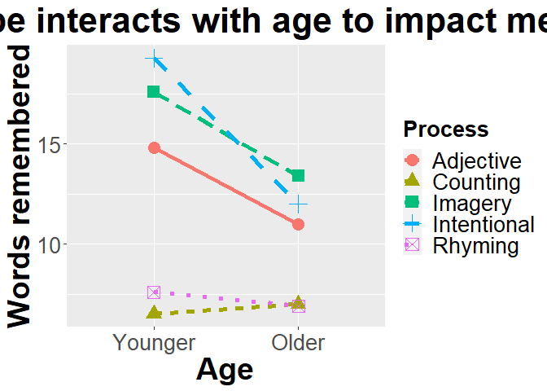

```r
function_output <- summarySE(memory, measurevar="Words", groupvars =
                               c("Age", "Process"), na.rm = T)
library(ggplot2)
ggplot(function_output, aes(x=Age, y=Words,color=Process,
                                   shape = Process)) +
  geom_line(aes(group=Process, linetype = Process), size=2) +
    geom_point(size = 5) +
  ylab("Words remembered")+
  xlab("Age") +
  ggtitle("Process type interacts with age to impact memory")+
  theme(axis.title.x = element_text(face="bold", size=28),
        axis.title.y = element_text(face="bold", size=28),
        axis.text.y  = element_text(size=20),
        axis.text.x  = element_text(size=20),
        legend.text =element_text(size=20),
        legend.title = element_text(size=20, face="bold"),
        plot.title = element_text(hjust = 0.5, face="bold", size=32))
```

There appears to be some interactions. Let’ build a model

```r
memory_interactions <- lm(Words ~ Age * Process, memory)
```

and check assumptions.

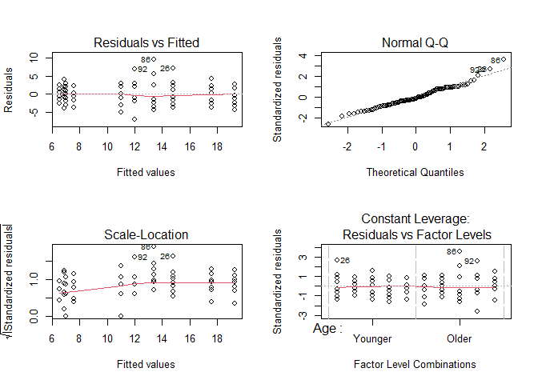

```r
par(mfrow=c(2,2))
plot(memory_interactions)
```

These appear to be met, so look at output

```r
library(car)
Anova(memory_interactions, type = "III")
```

```
## Anova Table (Type III tests)
##
## Response: Words
##             Sum Sq Df  F value    Pr(>F)
## (Intercept) 2190.4  1 272.9281 < 2.2e-16 ***
## Age           72.2  1   8.9963 0.0034984 **
## Process     1353.7  4  42.1690 < 2.2e-16 ***
## Age:Process  190.3  4   5.9279 0.0002793 ***
## Residuals    722.3 90
## ---
## Signif. codes:  0 '***' 0.001 '**' 0.01 '*' 0.05 '.' 0.1 ' ' 1
```

Since interaction is significant, analyze subsets. For example,

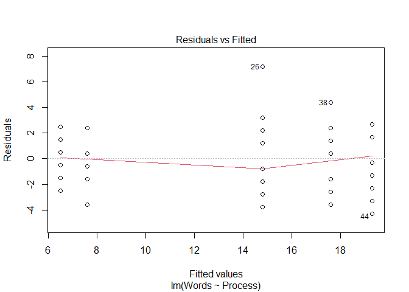

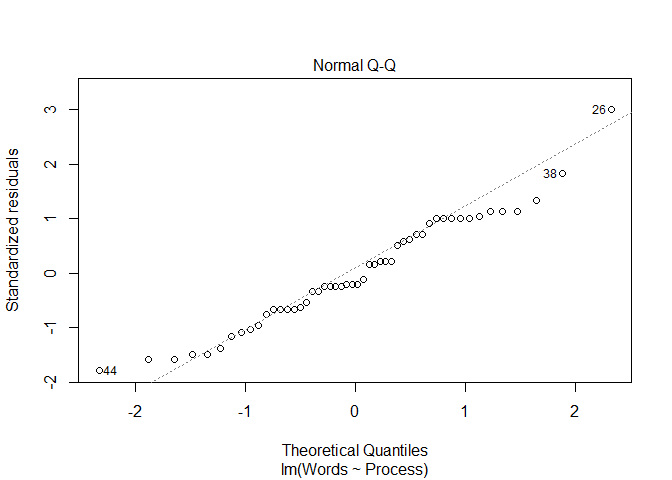

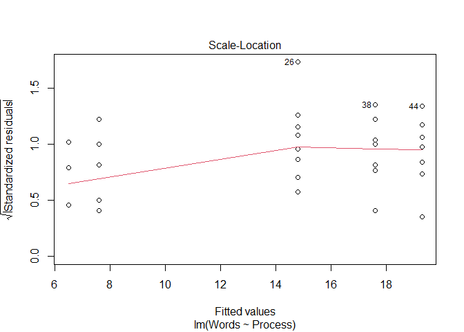

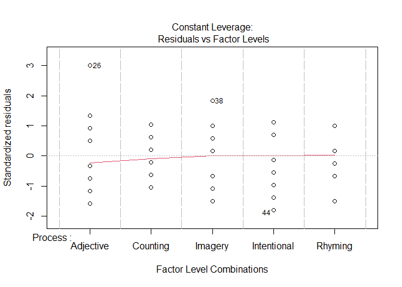

```r
memory_interactions_young <- lm(Words ~ Process, memory[memory$Age == "Younger",])
plot(memory_interactions_young)
```

```r
Anova(memory_interactions_young, type = "III")
```

```
## Anova Table (Type III tests)
##
## Response: Words
##             Sum Sq Df F value    Pr(>F)
## (Intercept) 2190.4  1 343.442 < 2.2e-16 ***
## Process     1353.7  4  53.064 < 2.2e-16 ***
## Residuals    287.0 45
## ---
## Signif. codes:  0 '***' 0.001 '**' 0.01 '*' 0.05 '.' 0.1 ' ' 1
```

There is a significant difference in words recalled based on process, but why? Investigate with post-hoc tests.

```r
library(multcomp)
comp_young <- glht(memory_interactions_young, linfct = mcp(Process = "Tukey"))
summary(comp_young)
```

```
##
##   Simultaneous Tests for General Linear Hypotheses
##
## Multiple Comparisons of Means: Tukey Contrasts
##
##
## Fit: lm(formula = Words ~ Process, data = memory[memory$Age == "Younger",
##     ])
##
## Linear Hypotheses:
##                              Estimate Std. Error t value Pr(>|t|)
## Counting - Adjective == 0      -8.300      1.129  -7.349  < 1e-04 ***
## Imagery - Adjective == 0        2.800      1.129   2.479  0.11357
## Intentional - Adjective == 0    4.500      1.129   3.984  0.00218 **
## Rhyming - Adjective == 0       -7.200      1.129  -6.375  < 1e-04 ***
## Imagery - Counting == 0        11.100      1.129   9.828  < 1e-04 ***
## Intentional - Counting == 0    12.800      1.129  11.333  < 1e-04 ***
## Rhyming - Counting == 0         1.100      1.129   0.974  0.86546
## Intentional - Imagery == 0      1.700      1.129   1.505  0.56456
## Rhyming - Imagery == 0        -10.000      1.129  -8.854  < 1e-04 ***
## Rhyming - Intentional == 0    -11.700      1.129 -10.359  < 1e-04 ***
## ---
## Signif. codes:  0 '***' 0.001 '**' 0.01 '*' 0.05 '.' 0.1 ' ' 1
## (Adjusted p values reported -- single-step method)
```

## Practice

### 1

1. A survey was conducted to see if athletes and non-athletes deal with anger in the same way. Data is @

angry <- read.csv(“https://docs.google.com/spreadsheets/d/e/2PACX-1vSaawG37o1ZUEs1B4keIJpZAY2c5tuljf29dWnzqQ0tHNCzfbz85AlWobYzBQ3nPPXJBLP-FWe4BNZB/pub?gid=1784556512&single=true&output=csv”, stringsAsFactors = T)

and more information is at

http://onlinestatbook.com/case_studies/angry_moods.html.

Focus on the following variables:

Sports 1 = athletes, 2 = non-athletes Gender 1 = males, 2 = females Expression (AE) index of general anger expression: (Anger-Out) + (Anger-In) - (Control-Out) - (Control-In) + 48

Is there any evidence that gender or athlete status impact how anger is expressed?

```r
angry <- read.csv("https://docs.google.com/spreadsheets/d/e/2PACX-1vSaawG37o1ZUEs1B4keIJpZAY2c5tuljf29dWnzqQ0tHNCzfbz85AlWobYzBQ3nPPXJBLP-FWe4BNZB/pub?gid=1784556512&single=true&output=csv", stringsAsFactors = T)
str(angry)
```

```
## 'data.frame':    78 obs. of  7 variables:
##  $ Gender          : int  2 2 2 2 1 1 1 2 2 2 ...
##  $ Sports          : int  1 1 1 1 1 1 1 1 1 1 ...
##  $ Anger.Out       : int  18 14 13 17 16 16 12 13 16 12 ...
##  $ Anger.In        : int  13 17 14 24 17 22 12 16 16 16 ...
##  $ Control.Out     : int  23 25 28 23 26 25 31 22 22 29 ...
##  $ Control.In      : int  20 24 28 23 28 23 27 31 24 29 ...
##  $ Anger_Expression: int  36 30 19 43 27 38 14 24 34 18 ...
```

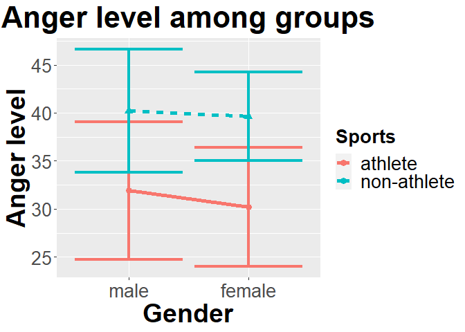

```r
angry$Gender <- as.factor(angry$Gender)
library(plyr)
angry$Gender <- revalue(angry$Gender, c("1" = "male",
                                        "2" = "female"))
angry$Sports <- as.factor(angry$Sports)
angry$Sports <- revalue(angry$Sports, c("1" = "athlete",
                                        "2" = "non-athlete"))
library(Rmisc)
anger_summary <- summarySE(angry, measurevar="Anger_Expression", groupvars =
                               c("Sports", "Gender"), na.rm = T)
library(ggplot2)
ggplot(anger_summary, aes(x=Gender, y=Anger_Expression, color=Sports,
                                   shape = Sports)) +
  geom_point(size = 3) +
  geom_line(aes(group=Sports, linetype =Sports), size=2) +
  geom_errorbar(aes(ymin=Anger_Expression-ci, ymax=Anger_Expression+ci), size=1.5) +
  ylab("Anger level")+
  xlab("Gender") +
  scale_shape_discrete(guide=FALSE)+
  scale_linetype_discrete(guide=FALSE)+
  ggtitle("Anger level among groups")+
  theme(axis.title.x = element_text(face="bold", size=28),
        axis.title.y = element_text(face="bold", size=28),
        axis.text.y  = element_text(size=20),
        axis.text.x  = element_text(size=20),
        legend.text =element_text(size=20),
        legend.title = element_text(size=20, face="bold"),
        plot.title = element_text(hjust = 0.5, face="bold", size=32))
```

*I first read in and recoded some data for ease and plotting. I then produced a plot to consider the null hypotheses that*

- *the sport an athlete plays does not influence anger level*
- *the gender of an athlete does not influence anger level*
- *the sport an athlete plays and their gender do not interact to influence anger level*

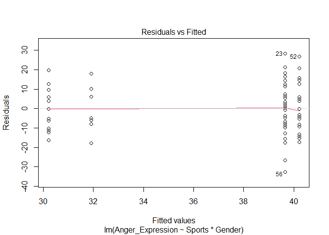

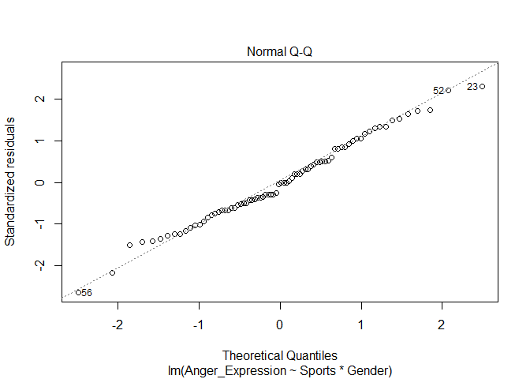

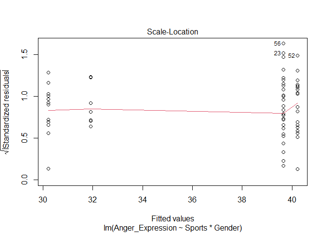

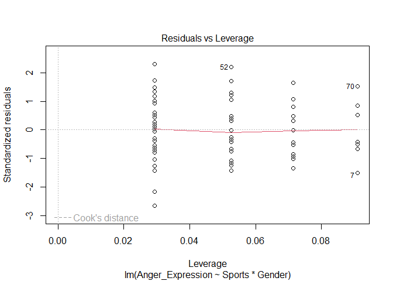

```r
angry_gender <- lm(Anger_Expression ~ Sports * Gender, angry)
plot(angry_gender)
```

```r
library(car)
Anova(angry_gender, type = "III")
```

```
## Anova Table (Type III tests)
##
## Response: Anger_Expression
##                Sum Sq Df F value    Pr(>F)
## (Intercept)   11200.1  1 71.8690 1.617e-12 ***
## Sports          480.1  1  3.0807   0.08336 .
## Gender           17.7  1  0.1135   0.73711
## Sports:Gender     5.2  1  0.0336   0.85505
## Residuals     11532.2 74
## ---
## Signif. codes:  0 '***' 0.001 '**' 0.01 '*' 0.05 '.' 0.1 ' ' 1
```

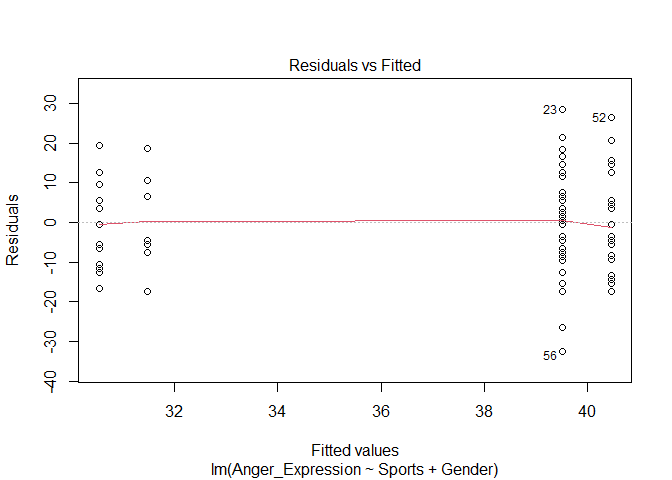

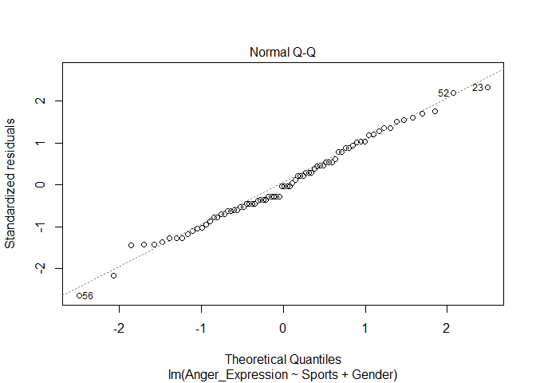

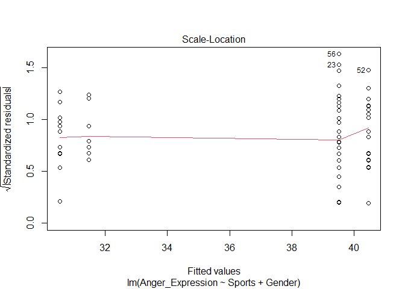

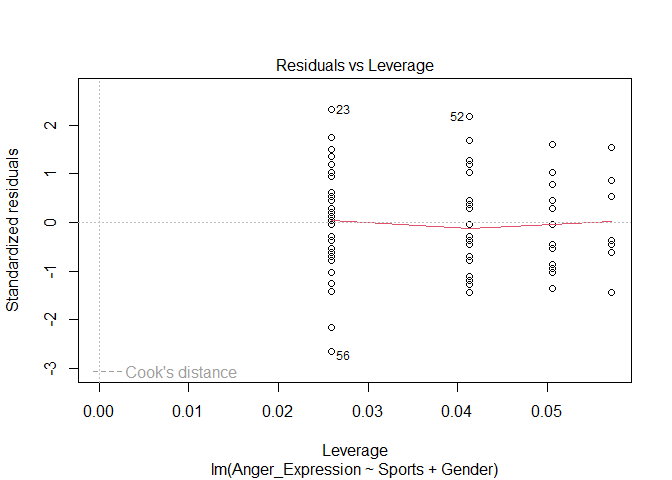

```r
#remove interaction since not significant
angry_gender <- lm(Anger_Expression ~ Sports + Gender, angry)
plot(angry_gender)
```

```r
Anova(angry_gender, type = "III") #only differs among those who play sports
```

```
## Anova Table (Type III tests)
##
## Response: Anger_Expression
##              Sum Sq Df  F value    Pr(>F)
## (Intercept) 17367.1  1 112.8964 < 2.2e-16 ***
## Sports       1357.2  1   8.8227  0.003995 **
## Gender         16.3  1   0.1061  0.745501
## Residuals   11537.4 75
## ---
## Signif. codes:  0 '***' 0.001 '**' 0.01 '*' 0.05 '.' 0.1 ' ' 1
```

### 2

2. A professor carried out a long-term study to see how various factors impacted pulse rate before and after exercise. Data can be found at http://www.statsci.org/data/oz/ms212.txt With more info at http://www.statsci.org/data/oz/ms212.html. Is there evidence that frequency of exercise (Exercise column) and gender impact change in pulse rate for students who ran (Ran column = 1)?

```r
pulse <- read.table("http://www.statsci.org/data/oz/ms212.txt", header = T,
                    stringsAsFactors = T)
pulse$Exercise <- factor(pulse$Exercise)
library(plyr)
pulse$Exercise <- revalue(pulse$Exercise, c("1" = "high",
                                            "2" = "moderate",
                                            "3" = "low"))
pulse$Gender <- factor(pulse$Gender)
pulse$Gender <- revalue (pulse$Gender, c("1" = "male", "2" = "female"))
pulse$change <- pulse$Pulse2 - pulse$Pulse1
change_summary <- summarySE(pulse[pulse$Ran == 1, ], measurevar="change", groupvars =
                               c("Exercise", "Gender"), na.rm = T)
```

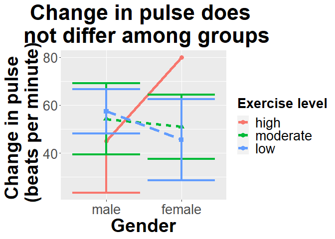

```r
ggplot(change_summary, aes(x=Gender, shape = Exercise, color = Exercise,
                           y=change)) +
  geom_point(size = 3) +
  geom_line(aes(group=Exercise, linetype =Exercise), size=2) +
  geom_errorbar(aes(ymin=change-ci, ymax=change+ci), size=1.5) +
  ylab("Change in pulse \n (beats per minute)") +
  scale_color_discrete(name = "Exercise level")+
  scale_shape_discrete(guide=FALSE)+
  scale_linetype_discrete(guide=FALSE)+
  ggtitle("Change in pulse does \n not differ among groups") +
  theme(axis.title.x = element_text(face="bold", size=28),
        axis.title.y = element_text(face="bold", size=28),
        axis.text.y  = element_text(size=20),
        axis.text.x  = element_text(size=20),
        legend.text =element_text(size=20),
        legend.title = element_text(size=20, face="bold"),
        plot.title = element_text(hjust = 0.5, face="bold", size=32))
```

*I first read in and recoded some data for ease and plotting. I then produced a plot to consider the null hypotheses that*

- *exercise level does not influence change in pulse rate*
- *gender does not influence change in pulse rate*
- *gender and exercise level do not interact to influence change in pulse rate*

```r
exercise <- lm(change ~ Gender * Exercise, pulse[pulse$Ran == 1, ])
summary(exercise)
```

```
##
## Call:
## lm(formula = change ~ Gender * Exercise, data = pulse[pulse$Ran ==
##     1, ])
##
## Residuals:
##     Min      1Q  Median      3Q     Max
## -44.231 -11.300   1.769  10.083  48.444
##
## Coefficients:
##                               Estimate Std. Error t value Pr(>|t|)
## (Intercept)                     45.000      8.746   5.145 7.44e-06 ***
## Genderfemale                    35.000     23.139   1.513   0.1383
## Exercisemoderate                 9.231     10.573   0.873   0.3879
## Exerciselow                     12.400     12.972   0.956   0.3449
## Genderfemale:Exercisemoderate  -38.231     24.678  -1.549   0.1292
## Genderfemale:Exerciselow       -46.844     26.043  -1.799   0.0796 .
## ---
## Signif. codes:  0 '***' 0.001 '**' 0.01 '*' 0.05 '.' 0.1 ' ' 1
##
## Residual standard error: 21.42 on 40 degrees of freedom
## Multiple R-squared:  0.0828, Adjusted R-squared:  -0.03185
## F-statistic: 0.7222 on 5 and 40 DF,  p-value: 0.6107
```

```r
Anova(exercise, type = "III")
```

```
## Anova Table (Type III tests)
##
## Response: change
##                  Sum Sq Df F value    Pr(>F)
## (Intercept)     12150.0  1 26.4739 7.444e-06 ***
## Gender           1050.0  1  2.2879    0.1383
## Exercise          496.3  2  0.5407    0.5865
## Gender:Exercise  1488.8  2  1.6220    0.2102
## Residuals       18357.7 40
## ---
## Signif. codes:  0 '***' 0.001 '**' 0.01 '*' 0.05 '.' 0.1 ' ' 1
```

```r
#rerun without interaction
exercise <- lm(change ~ Gender + Exercise, pulse[pulse$Ran == 1, ])
summary(exercise)
```

```
##
## Call:
## lm(formula = change ~ Gender + Exercise, data = pulse[pulse$Ran ==
##     1, ])
##
## Residuals:
##    Min     1Q Median     3Q    Max
## -43.99 -14.89   2.23  11.91  45.19
##
## Coefficients:
##                  Estimate Std. Error t value Pr(>|t|)
## (Intercept)        50.391      8.273   6.091 2.94e-07 ***
## Genderfemale       -2.738      6.770  -0.404    0.688
## Exercisemoderate    3.603      9.572   0.376    0.708
## Exerciselow         1.155     10.617   0.109    0.914
## ---
## Signif. codes:  0 '***' 0.001 '**' 0.01 '*' 0.05 '.' 0.1 ' ' 1
##
## Residual standard error: 21.74 on 42 degrees of freedom
## Multiple R-squared:  0.008416,   Adjusted R-squared:  -0.06241
## F-statistic: 0.1188 on 3 and 42 DF,  p-value: 0.9485
```

```r
Anova(exercise, type = "III") #no significance
```

```
## Anova Table (Type III tests)
##
## Response: change
##              Sum Sq Df F value    Pr(>F)
## (Intercept) 17532.0  1 37.1019 2.937e-07 ***
## Gender         77.3  1  0.1636    0.6879
## Exercise       97.1  2  0.1028    0.9025
## Residuals   19846.5 42
## ---
## Signif. codes:  0 '***' 0.001 '**' 0.01 '*' 0.05 '.' 0.1 ' ' 1
```

### 3

3. (Continuing from question 2) I’m curious if the treatment (running vs not) even had an impact, and if so did it depend on gender. How would you test this?

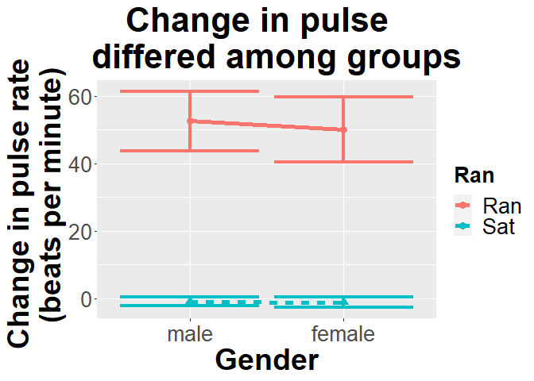

```r
pulse$Ran <- factor(pulse$Ran)
pulse$Ran <- revalue(pulse$Ran, c("1" = "Ran", "2" = "Sat"))
run_summary <- summarySE(pulse, measurevar="change", groupvars =
                               c("Ran", "Gender"), na.rm = T)

ggplot(run_summary, aes(x=Gender, shape = Ran, color = Ran,
                           y=change)) +
  geom_point(size = 3) +
  geom_line(aes(group=Ran, linetype = Ran), size=2) +
  geom_errorbar(aes(ymin=change-ci, ymax=change+ci), size=1.5) +
  ylab("Change in pulse rate \n (beats per minute)") +
  xlab("Gender")+
  ggtitle("Change in pulse  \n  differed among groups") +
  scale_color_discrete(name = "Ran")+
  scale_shape_discrete(guide=FALSE)+
  scale_linetype_discrete(guide=FALSE)+
  theme(axis.title.x = element_text(face="bold", size=28),
        axis.title.y = element_text(face="bold", size=28),
        axis.text.y  = element_text(size=20),
        axis.text.x  = element_text(size=20),
        legend.text =element_text(size=20),
        legend.title = element_text(size=20, face="bold"),
        plot.title = element_text(hjust = 0.5, face="bold", size=32))
```

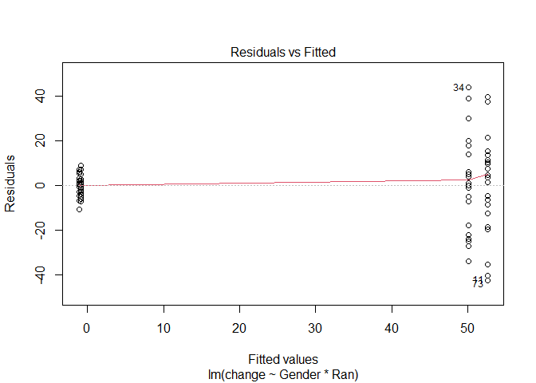

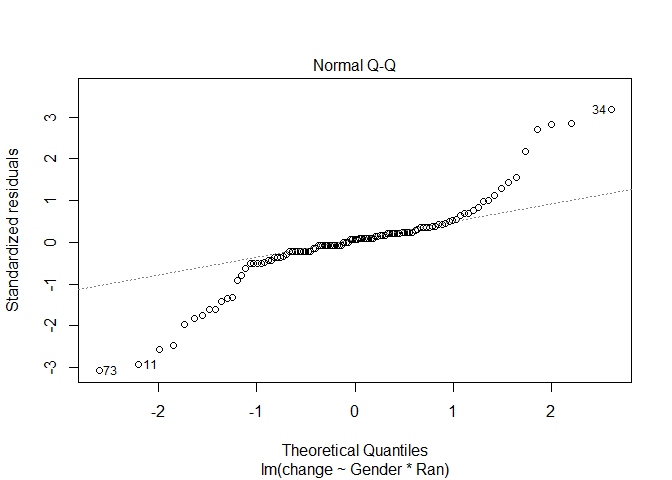

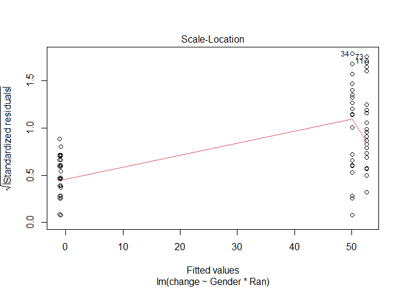

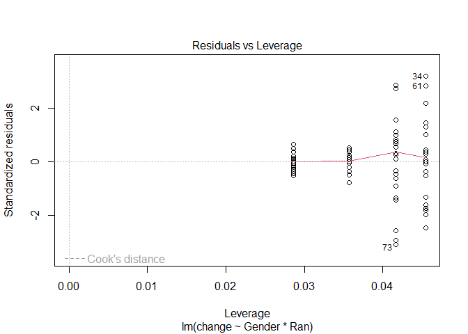

```r
pulse$Ran <- as.factor(pulse$Ran)
levels(pulse$Ran) <- c("ran", "sat")
running <- lm(change ~ Gender * Ran, pulse)
plot(running)
```

```r
Anova(running, type = "III")
```

```
## Anova Table (Type III tests)
##
## Response: change
##             Sum Sq  Df  F value Pr(>F)
## (Intercept)  66360   1 333.4351 <2e-16 ***
## Gender          71   1   0.3583 0.5508
## Ran          40747   1 204.7387 <2e-16 ***
## Gender:Ran      35   1   0.1755 0.6761
## Residuals    20897 105
## ---
## Signif. codes:  0 '***' 0.001 '**' 0.01 '*' 0.05 '.' 0.1 ' ' 1
```

```r
#consider without interaction
running <- lm(change ~ Gender + Ran, pulse)
Anova(running, type = "III")  #running mattered
```

```
## Anova Table (Type III tests)
##
## Response: change
##             Sum Sq  Df  F value Pr(>F)
## (Intercept)  89366   1 452.5490 <2e-16 ***
## Gender          37   1   0.1872 0.6662
## Ran          73006   1 369.7027 <2e-16 ***
## Residuals    20932 106
## ---
## Signif. codes:  0 '***' 0.001 '**' 0.01 '*' 0.05 '.' 0.1 ' ' 1
```

```r
summary(running) #running increased pulse
```

```
##
## Call:
## lm(formula = change ~ Gender + Ran, data = pulse)
##
## Residuals:
##    Min     1Q Median     3Q    Max
## -41.95  -3.52   0.48   4.48  43.22
##
## Coefficients:
##              Estimate Std. Error t value Pr(>|t|)
## (Intercept)    51.951      2.442  21.273   <2e-16 ***
## Genderfemale   -1.169      2.703  -0.433    0.666
## Ransat        -52.431      2.727 -19.228   <2e-16 ***
## ---
## Signif. codes:  0 '***' 0.001 '**' 0.01 '*' 0.05 '.' 0.1 ' ' 1
##
## Residual standard error: 14.05 on 106 degrees of freedom
##   (1 observation deleted due to missingness)
## Multiple R-squared:  0.7772, Adjusted R-squared:  0.773
## F-statistic: 184.9 on 2 and 106 DF,  p-value: < 2.2e-16
```

*After plotting the data, I used a linear model to test the null hypotheses that* * *change in pulse rate did not depend on gender* * *change in pulse rate did not depend on running treatment* * *there was no interaction between running treatment and gender on change in pulse rate*